# Classification of Human Activity Using Measurements from Wearable Devices

Leonard Wee

24 August 2014

# Introduction

Human activity recognition using wearable physical measurement devices is an active area for data science research. The quantity of physical activity data continues to grow, but further work is required to understand how to reliably assign meaning to this data.

A promising line of inquiry that might successfully bridge the data-to-understanding gap is machine-learning classifiers/predictors that recognise discrete modes of human activity (e.g. correct versus incorrect weight-lifting exercises).

# Data Source

The data for this R-based project is the Weight Lifting Exercise Dataset (http://groupware.les.inf.puc-rio.br/har#weight_lifting_exercises) by Velloso et al.

Six healthy volunteers had been asked to perform one set of 10 repetitions of Unilateral Dumbbell Bicep Curls in all of five different modes :  
- correctly according to international exercise specification (Class A),  
- throwing elbows towards the front (Class B),  
- half dumbbell lifts (Class C),  
- lowering the dumbbell halfway (Class D), and  
- throwing hips towards the front (Class E).

The training data is downloadable here : https://d396qusza40orc.cloudfront.net/predmachlearn/pml-training.csv

The raw training data consists of 19622 rows of 160 variables, of which the last column is the known classification of the exercise. The data consists of accelerometer, gyroscope and magnetometer measurements from devices placed respectively on a volunteer’s forearm, wrist, hip belt and directly on the dumbbell.

The final testing data of 20 distinct observations can be obtained here : https://d396qusza40orc.cloudfront.net/predmachlearn/pml-testing.csv

# Data Pre-processing

## Non-value columns for prediction

To prepare the training data for machine learning, the columns of the *testing* data set was inspected for containing no data except NA. Since only the non-NA columns could be used for the prediction exercise, only these columns were retained in the *training* data set. The result of this pre-process was a data frame of 60 columns.

## Date, time and identifier columns

The machine-based classifier must not be trained against non-measurements in the data, such as time-date stamps, frame counts or subject identifiers. Therefore, the first seven columns were also removed from the training data set. The result of this pre-process was a data frame of 53 columns.

## Checks for zero or nearly-zero variances

Parameters which do not vary much (or none at all) do not contribute to classifier learning, therefore it is advisable to check for these. A rapid check concluded that usable variance was observed in all the above 53 columns.

```
nzv <- nearZeroVar(indata[,-53], saveMetrics = TRUE)
if (sum(nzv$nzv) > 0) {
      print("Warning - there are parameters with zero or near-zero variance.")
      }
rm(nzv)
```

## Tighly-correlated parameters

Inclusion of redundant parameters introduces the possibility of mistaken learning and/or longer computation times for classifier training. The latter is noteworthy since bootstrapping and resampling algorithms will be included. Tighly-correlated values (threshold correlation coefficient = 0.90) were removed to created a *correlation-filtered training* data set.

```
highlyCor <- findCorrelation(cor(indata[,-53]), cutoff = 0.90)
filteredInData <- indata[,-highlyCor]
```

The result of this pre-process was a *new* data frame of 46 columns.

# Classifier Training

Two candidate classifiers were trained on the pre-processed training data (52 parameters) as well as on the correlation-filtered training data (45 parameters), leading to four accuracy metrics to assess by cross-validation.

Multi-linear regression-based models were not used for this discrete 5-factor classification problem, because a linear coefficient variation between the parameters for each class of activity was not expected a priori.

Further, the use of tree-based classification was preferable for this problem because such methods are more robust with respect to the skewness or asymmetric distribution of parameter values.

*No data was pre-processed by centre and scaling prior to training and testing.*

## Internal cross-validation

For each classification candidate, the in-sample accuracy was assessed using **repeated 10-fold cross-validation with 5 repetitions**. To apply this consistently across all candidate classifiers, the following **trainControl** object in the package “caret” was defined :

```
fitControl <- trainControl(
      ## 10-fold repeated cross-validation
      method = "repeatedcv", number = 10,
      ## repeated five times
      repeats = 5
      ## no pre-processing scaling and centering not critical for tree methods
      )
```

## Simple tree-based classification design

A simple decision tree was implemented using an “rpart” method call inside of “caret”, with a range of tunable complexity parameters set by the argument **tuneGrid** :

```
set.seed(33524) #set initial seed
## learning object 1 : simple classification tree with all 52 variables
treeFit1 <- train(classe ~ ., data = indata, method = "rpart",
                  trControl = fitControl,
                  tuneGrid = expand.grid(.cp=c(0.0001,0.001,0.003,0.01,0.03,0.1))
                  )
## learning object 2 : simple classification tree with 45 correlation-filtered variables
set.seed(33524) #set initial seed
treeFit2 <- train(classe ~ ., data = filteredInData, method = "rpart",
                  trControl = fitControl,
                  tuneGrid = expand.grid(.cp=c(0.0001,0.001,0.003,0.01,0.03,0.1))
)
```

The complexity parameter sets controls the penalty for introducing an additional branch in the decision tree, therefore low values correspond more closely to unconstrained trees.

The in-sample cross-validation accuracy depends strongly on the complexity parameter, with the best accuracy result occurring at the lowest value of the tuning parameter. For larger values of the complexity parameter, training on the processed data set with 52 parameters slightly performed marginally better than training with 45 parameters in the correlation-filtered data set. A graphical assessment of the performance against complexity parameter is shown below in Figure 1.

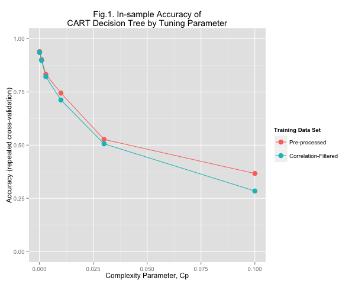

## Random-forest classification design

A random-forest decision tree was implemented using an “rf” method call inside of “caret”, with a range of four tunable “mtry” parameters set by the argument **tuneGrid** :

```
## learning object 3 : random forest classification with all variables
set.seed(33524) #reset initial seed
forestFit1 <- train(classe ~ ., data = indata, method = "rf",
                    trControl = fitControl,
                    tuneGrid = expand.grid(.mtry=c(23,27,45,52))
                    )
## learning object 4 : random forest classification with correlation-filtered variables
set.seed(33524) #reset initial seed
forestFit2 <- train(classe ~ ., data = filteredInData, method = "rf",
                    trControl = fitControl,
                    tuneGrid = expand.grid(.mtry=c(23,27,45))
                    )
```

The performance of the random forest classifier was uniformly very high (always above 99% accuracy) and was roughly insensitive to the number of parameters sampled in each tree (mtry). The best accuracy in both classifiers was obtained for *mtry = 23*. There was no notable differences in performance between the cleaned training set versus the correlation-filtered training set. The resampling profile dependence on *mtry* is shown below in Figure 2.

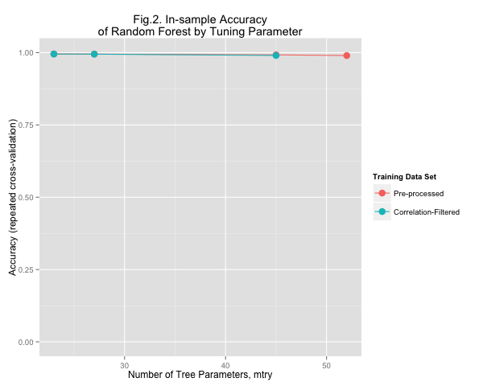

## Estimating of out-of-sample accuracy

The optimal performance for either of the CART-based classifiers was obtained for the lowest complexity parameter (*Cp = 0.0001*), resulting in a cross-validation accuracy of 94.0% (SD 0.6%) for the 52-parameter training set versus 93.5% (SD 0.6%) for the correlation-filtered 45-parameter data set.

Since robust internal cross-validation was used, the expected out-of-sample accuracy has been reliably estimated. However, since cross-validation is known to over-estimate the out-of-sample accuracy, it would be conservative to state the lower limit of the expected accuracy.

**Therefore, in a final test sample, it is expected that the CART-based simple trees should correctly predict 18 out of the 20 test cases. The random forest algorithm is expected to correctly predict 20 out of the 20 test cases.**

## Classifier selection

In spite of the significantly longer computation time, the random forest approach was clearly superior to the simple decision tree-based method.

The cross-validation accuracy was not dependent on the number of columns in the training data set, however CPU time was reduced by approximately 30% when using the correlation-filtered training data.

To proceed to the one-time final test, the predicted classifications of the 20 test cases were saved as a vector of factors :

```
answer <- predict(forestFit2, newdata=finalTest)
```

File formats for upload and submission to the Coursera assignment page were processed using the *pml_write_files* given in the project instructions.

# Results of Final Test

In the final test, the above classifier was applied to the quarantined sample of 20 test cases. As expected, the random-forest classifier based on the correlation-filtered training set was successfully able to predict 20 out of the 20 test cases (success rate = 100%).

The final test sample size was recognised to be presently too small to accurately estimate an out-of-sample overall sensitivity and specificity of correct (versus incorrect) classifications physical activity, nor was it possible to generate confusion matrices for predicted and true classifications.

# Conclusion

A random forest machine learning algorithm has been trained on a 23-parameter decision tree using a 45-parameter training data set. Internal 10-fold cross-validation was repeated 5 times to generate an estimate of the learning accuracy (99.5% with a standard deviation of 0.2%). The above classifier correctly predicted the physical activity classification for 20 out of 20 quarantined test instances.

More information about the weight-lifting data set may be found at: http://groupware.les.inf.puc-rio.br/har#weight_lifting_exercises#ixzz39tstDjrm

More details on the “caret” package may be located at CRAN : http://caret.r-forge.r-project.org

# References

E. Velloso, A. Bulling, H. Gellersen, W. Ugulino, H. Fuks (2013) Qualitative Activity Recognition of Weight Lifting Exercises, **Proceedings of 4th International Conference in Cooperation with SIGCHI** Stuttgart, Germany: ACM SIGCHI, 2013.